# Midterm (backup version)

## Visualization

(The [`janitor`](http://sfirke.github.io/janitor/) package provides some convenient [utilities](http://sfirke.github.io/janitor/articles/janitor.html) for cleaning data. Here we used `clean_names` to make sane formatting for all of the names.)

Let’s take a quick look at the data:

```r
car_prices %>% head()
```

```
## # A tibble: 6 x 12
##    price mileage make  model trim  type  cylinder liter doors cruise sound
##    <dbl>   <dbl> <chr> <chr> <chr> <chr>    <dbl> <dbl> <dbl>  <dbl> <dbl>
## 1 17314.    8221 Buick Cent… Seda… Sedan        6   3.1     4      1     1
## 2 17542.    9135 Buick Cent… Seda… Sedan        6   3.1     4      1     1
## 3 16219.   13196 Buick Cent… Seda… Sedan        6   3.1     4      1     1
## 4 16337.   16342 Buick Cent… Seda… Sedan        6   3.1     4      1     0
## 5 16339.   19832 Buick Cent… Seda… Sedan        6   3.1     4      1     0
## 6 15709.   22236 Buick Cent… Seda… Sedan        6   3.1     4      1     1
## # … with 1 more variable: leather <dbl>
```

```r
car_prices %>% glimpse()
```

```
## Rows: 804
## Columns: 12
## $ price    <dbl> 17314.10, 17542.04, 16218.85, 16336.91, 16339.17, 15709.05, …
## $ mileage  <dbl> 8221, 9135, 13196, 16342, 19832, 22236, 22576, 22964, 24021,…
## $ make     <chr> "Buick", "Buick", "Buick", "Buick", "Buick", "Buick", "Buick…
## $ model    <chr> "Century", "Century", "Century", "Century", "Century", "Cent…
## $ trim     <chr> "Sedan 4D", "Sedan 4D", "Sedan 4D", "Sedan 4D", "Sedan 4D", …
## $ type     <chr> "Sedan", "Sedan", "Sedan", "Sedan", "Sedan", "Sedan", "Sedan…
## $ cylinder <dbl> 6, 6, 6, 6, 6, 6, 6, 6, 6, 6, 6, 6, 6, 6, 6, 6, 6, 6, 6, 6, …
## $ liter    <dbl> 3.1, 3.1, 3.1, 3.1, 3.1, 3.1, 3.1, 3.1, 3.1, 3.1, 3.6, 3.6, …
## $ doors    <dbl> 4, 4, 4, 4, 4, 4, 4, 4, 4, 4, 4, 4, 4, 4, 4, 4, 4, 4, 4, 4, …
## $ cruise   <dbl> 1, 1, 1, 1, 1, 1, 1, 1, 1, 1, 1, 1, 1, 1, 1, 1, 1, 1, 1, 1, …
## $ sound    <dbl> 1, 1, 1, 0, 0, 1, 1, 1, 0, 1, 0, 1, 1, 1, 1, 1, 0, 1, 1, 1, …
## $ leather  <dbl> 1, 0, 0, 0, 1, 0, 0, 0, 1, 1, 0, 0, 0, 1, 1, 0, 0, 1, 0, 1, …
```

### Reproduce a plot

#### Price by Mileage

**Write code to reproduce the following visualization**, intended to show that lower-mileage cars tend to be valued more highly.

Tips:

- See the [Visualization Tweaks](https://cs.calvin.edu/courses/data/202/fa20/notes/visualization.html#tweaks) section of the course notes for tips on the scales.

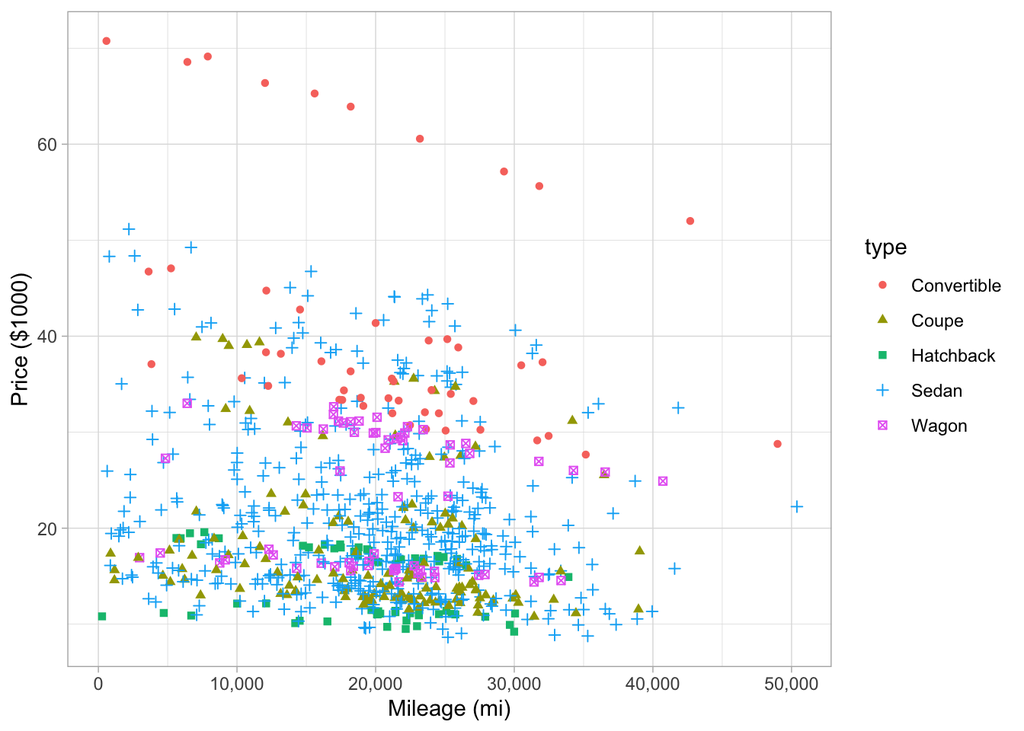

**Extra credit (save this for last!)**: can you figure out how to make this plot? It shows the same data in each pane, but highlights the cars of each given type.

Tip: two `geom_point` layers, one with `data` set to `car_prices` *without the `type` column*.

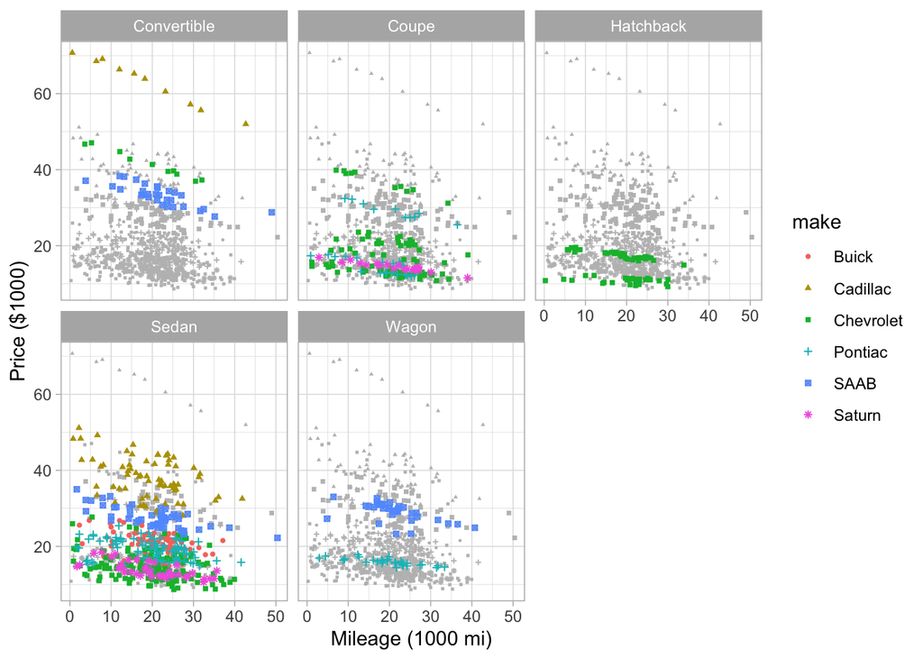

### High or Low Mileage

**Write code to reproduce the following visualization**, intended to show whether mileage affects price differently for different types of cars. Consider a car to be “low mileage” if its mileage is less than the median mileage.

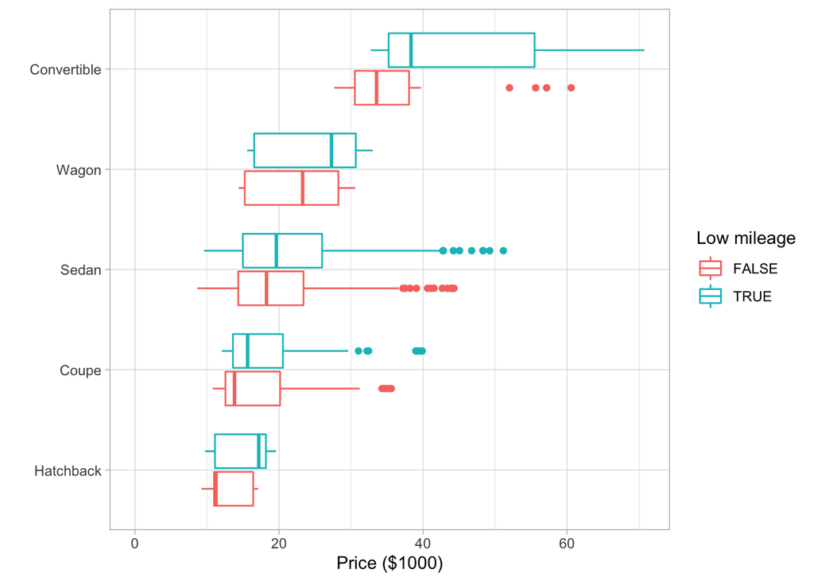

## Data Wrangling

**What was the most common car `make` in this data set?**

**Make a table** showing, for each car `type`, what proportion of the listed cars had cruise control. Note that the `cruise` column contains a 1 if the listed car has cruise control, 0 if it doesn’t, so you can use math functions here. Your table should have 5 rows. **Sort the table from highest to lowest fraction**.

Which car type **least frequently** had cruise control?

Do 2-door cars or 4-door (`doors`) cars have bigger engines (`liter` column) on average in this data set?

## Align, Combine, and Reshape

```r
fuel_eco <- read_csv("data/guide2005-2004oct15.csv") %>% janitor::clean_names()
```

Notable columns are (descriptions are quoted from the EPA’s [guide](https://www.fueleconomy.gov/feg/pdfs/guides/FEG2005.pdf)):

- `manufacturer` and `carline_name`: the make and model of the car tested.
- `cty`: *City* represents urban driving, in which a vehicle is started in the morning (after being parked all night) and driven in stop-and-go rush hour traffic
- `hwy`: *Highway* represents a mixture of rural and interstate highway driving in warmed-up vehicles, typical of longer trips in free-flowing traffic.
- `cmb`: *Combined* city and highway MPG estimates … assume you will drive 55% in the city and 45% on the highway.

(Full documentation from the source is available [here](https://www.fueleconomy.gov/feg/epadata/Readme.txt) but is not needed for these exercises.)

We first briefly verify that the *carline name* is sufficiently unique to describe a car; there are no cars with the same name but different manufacturers:

```r
fuel_eco %>% distinct(carline_name) %>% nrow()
```

```
## [1] 540
```

```r
fuel_eco %>% distinct(manufacturer, carline_name) %>% nrow()
```

```
## [1] 540
```

Good to go. But a brief look at the dataset immediately reveals two potential problems:

```r
fuel_eco %>% select(manufacturer, carline_name, cty, hwy, cmb) %>% head(5)
```

```
## # A tibble: 5 x 5
##   manufacturer carline_name          cty   hwy   cmb
##   <chr>        <chr>               <dbl> <dbl> <dbl>
## 1 ACURA        NSX                    17    24    20
## 2 ACURA        NSX                    17    24    20
## 3 AUDI         TT ROADSTER            20    28    23
## 4 AUDI         TT ROADSTER QUATTRO    20    29    23
## 5 AUDI         TT ROADSTER QUATTRO    22    27    24
```

*First problem*: *each car may be reported several times* in the EPA dataset, once for each different engine option or transmission type. We could work out some of that data from the `trim` column, but for a first pass, let’s just take the *average* mileages for a given `carline_name`.

**Make a table called `fuel_eco_avg`** that gives the average `cty`, `hwy`, and `cmb` fuel economy for each `manufacturer` and `carline_name`. While you’re at it, use more sensible names: `city`, `highway`, and `combined`. The result should look like:

```
## # A tibble: 540 x 5
## # Groups:   manufacturer [43]
##    manufacturer carline_name    city highway combined
##    <chr>        <chr>          <dbl>   <dbl>    <dbl>
##  1 ACURA        MDX 4WD         17      23       19
##  2 ACURA        NSX             17      24       20
##  3 ACURA        RL              18      26       21
##  4 ACURA        RSX             25      33       28
##  5 ACURA        TL              20      29       23
##  6 ACURA        TSX             21.5    30.5     24.5
##  7 ASTON MARTIN DB9             11      19       14
##  8 ASTON MARTIN DB9 VOLANTE     11      18       14
##  9 ASTON MARTIN V12 VANQUISH S  11      17       13
## 10 AUDI         A4              22      29.7     24.7
## # … with 530 more rows
```

*Second problem*: the EPA uses all-caps for car names but the Kelly Blue Book didn’t. So none of the EPA’s `carline_name`s in `fuel_eco` will match the `model`s in `car_prices`. Let’s look at `car_prices` again for reference:

```r
car_prices %>% distinct(make, model) %>% head(5)
```

```
## # A tibble: 5 x 2
##   make     model
##   <chr>    <chr>
## 1 Buick    Century
## 2 Buick    Lacrosse
## 3 Buick    Lesabre
## 4 Buick    Park Avenue
## 5 Cadillac CST-V
```

But we won’t let that stop us! Here’s a strategy: ignore case. Specifically:

**Make a table called `car_prices_and_eco`** that has the city, highway, and combined fuel economy for all of the cars in `car_prices`. To ignore case in the matching, *upper-case* (`str_to_upper()`) the models in `car_prices` and put the result in a *new column*, which you can then use to look up fuel economies in `fuel_eco_avg`. For cars that don’t match the EPA data even after ignoring case, leave the fuel economies at `NA` (don’t drop the row).

Tip: how many rows should the result have?

**How many distinct car models didn’t match the EPA data?**

**Reproduce the following graph** using the `car_prices_and_eco` dataset.

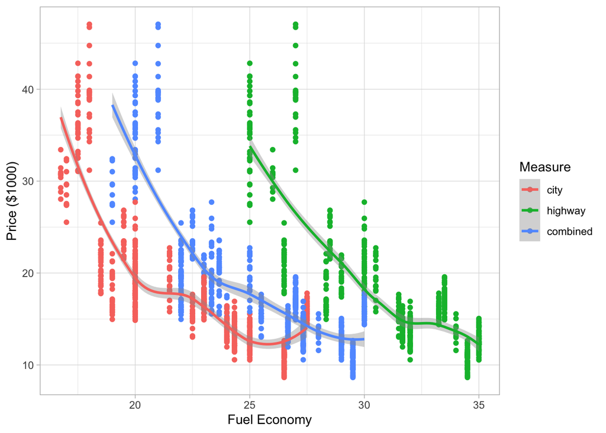

*Note*: I used `fct_relevel` to adjust the order of the measures, but you may leave it at the default order for full credit.

## Modeling

Let’s try to make some models to predict `price`.

We’ll hold out a testing set so we can validate our model.

```r
set.seed(0)
cars_split <- initial_split(car_prices, prop = 3/4, strata = "make")
cars_train <- training(cars_split)
cars_test <- testing(cars_split)
```

First, create a `tidymodels` model called `model` that predicts `price` from `mileage` using linear regression on the training set. (You do not need a recipe here.)

Then, write code to recreate the following plot, which shows how the *residuals* (actual minus predicted) depend on the car type. Plots like this can be useful for showing whether it’s helpful to add additional features to the predictive model.

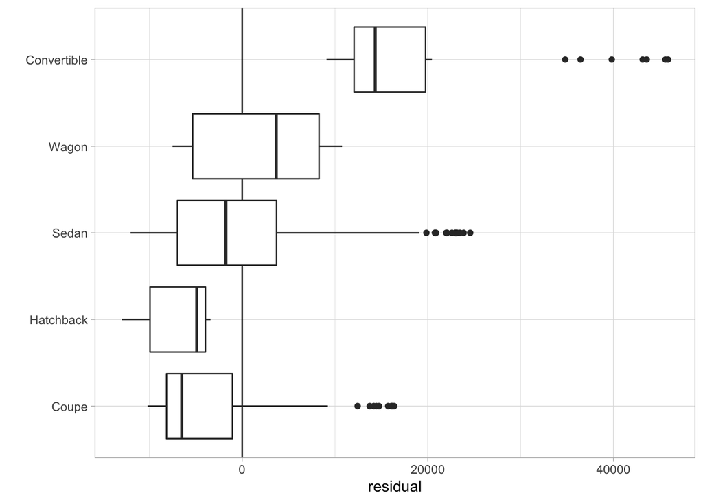

*Note*: We’re stopping short of a full predictive modeling workflow to keep this midterm at a manageable length.